# JobMarketInsights

Home

```python
import pandas as pd
import numpy as np
import matplotlib.pyplot as plt
import seaborn as sns
import matplotlib.patches as mpatches
```

INTRODUCTION

We are provided with a dataset offering insights into the AI-driven job market, containing 10 columns as described:

```
Job_Title: (Categorical) Title of the role.
Industry: (Categorical) Industry the job belongs to.
Company_Size: (Categorical) "Small", "Medium", or "Large".
Location: (Categorical) Geographic location of the role.
AI_Adoption_Level: (Categorical) Extent of AI adoption in the role.
Automation_Risk: (Categorical) Likelihood of job automation in the next 10 years.
Required_Skills: (Categorical) Key skills required for the role.
Salary_USD: (Numeric) Annual salary in USD.
Remote_Friendly: (Categorical) Indicates whether the job can be performed remotely.
Job_Growth_Projection: (Categorical) Projected growth or decline of the role over the next five years.
```

There are no missing values in the dataset, allowing us to proceed with the analysis. In the following sections, we will explore several insights, such as how AI adoption influences salary and job growth, which industries face the highest automation risks, and the extent to which roles offer remote flexibility. Additionally, we will examine the skills associated with automation risks and investigate whether company size affects AI adoption and job growth projections.

RESULTS

```python
df = pd.read_csv('ai_job_market_insights.csv')
```

```python
df.head()
```

|  | Job_Title | Industry | Company_Size | Location | AI_Adoption_Level | Automation_Risk | Required_Skills | Salary_USD | Remote_Friendly | Job_Growth_Projection |
| --- | --- | --- | --- | --- | --- | --- | --- | --- | --- | --- |
| 0 | Cybersecurity Analyst | Entertainment | Small | Dubai | Medium | High | UX/UI Design | 111392.165243 | Yes | Growth |
| 1 | Marketing Specialist | Technology | Large | Singapore | Medium | High | Marketing | 93792.562466 | No | Decline |
| 2 | AI Researcher | Technology | Large | Singapore | Medium | High | UX/UI Design | 107170.263069 | Yes | Growth |
| 3 | Sales Manager | Retail | Small | Berlin | Low | High | Project Management | 93027.953758 | No | Growth |
| 4 | Cybersecurity Analyst | Entertainment | Small | Tokyo | Low | Low | JavaScript | 87752.922171 | Yes | Decline |

```python
df.info()
```

```
<class 'pandas.core.frame.DataFrame'>
RangeIndex: 500 entries, 0 to 499
Data columns (total 10 columns):
 #   Column                 Non-Null Count  Dtype
---  ------                 --------------  -----
 0   Job_Title              500 non-null    object
 1   Industry               500 non-null    object
 2   Company_Size           500 non-null    object
 3   Location               500 non-null    object
 4   AI_Adoption_Level      500 non-null    object
 5   Automation_Risk        500 non-null    object
 6   Required_Skills        500 non-null    object
 7   Salary_USD             500 non-null    float64
 8   Remote_Friendly        500 non-null    object
 9   Job_Growth_Projection  500 non-null    object
dtypes: float64(1), object(9)
memory usage: 39.2+ KB
```

# Part 1: Which industries are the safest to enter?

### Task 1: Which industry does AI pose the largest threat to?

```python
grouped = df.groupby(['Industry', 'Automation_Risk']).size().unstack(fill_value=0)
grouped_percent = grouped.div(grouped.sum(axis=1), axis=0) * 100
```

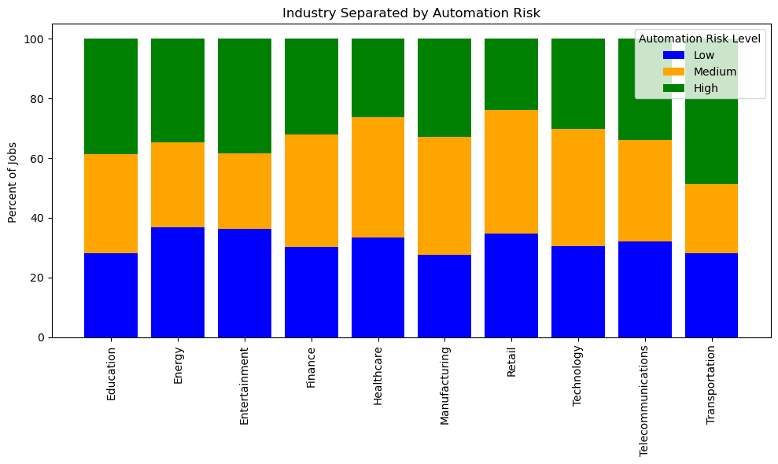

```python
industries = grouped.index
low_risk = grouped_percent['Low']
medium_risk = grouped_percent['Medium']
high_risk = grouped_percent['High']

plt.figure(figsize=(10, 6))

# Stacked bars
plt.bar(industries, low_risk, label='Low', color='blue')
plt.bar(industries, medium_risk, bottom=low_risk, label='Medium', color='orange')
plt.bar(industries, high_risk, bottom=low_risk+medium_risk, label='High', color='green')

# Rotate x-ticks for better readability
plt.xticks(rotation=90)

# Add a title, y-axis, and legend
plt.title("Industry Separated by Automation Risk")
plt.legend(title='Automation Risk Level')
plt.ylabel("Percent of Jobs ")
# Show the plot
plt.tight_layout()
plt.show()
```

### Task 2: Which Industry will see the highest job growth?

```python
grouped = df.groupby(['Industry', 'Job_Growth_Projection']).size().unstack(fill_value=0)
grouped_percent = grouped.div(grouped.sum(axis=1), axis=0) * 100
```

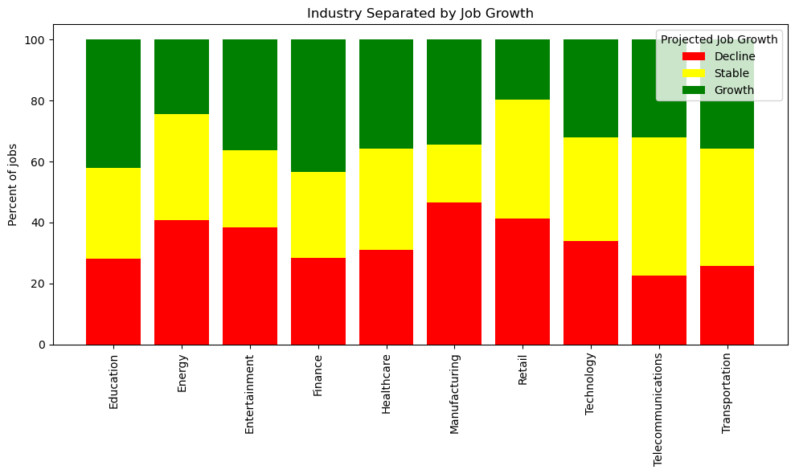

```python
industries = grouped.index
growth = grouped_percent['Growth']
stable = grouped_percent['Stable']
decline = grouped_percent['Decline']

plt.figure(figsize=(10, 6))

# Stacked bars
plt.bar(industries, decline, label='Decline', color='red')
plt.bar(industries, stable, bottom=decline, label='Stable', color='yellow')
plt.bar(industries, growth, bottom=decline+stable, label='Growth', color='green')

# Rotate x-ticks for better readability
plt.xticks(rotation=90)

# Add a title, y-axis, and legend
plt.title("Industry Separated by Job Growth")
plt.legend(title='Projected Job Growth')
plt.ylabel("Percent of jobs")
# Show the plot
plt.tight_layout()
plt.show()
```

The job growth chart shows the education and finance sector will see the most growth, and manufacturing the largest decline. Energy shows a demising 40% decline rate, while transportation also shows steady job growth despite its higher automation risk.

# Part 2: Which jobs would be considered most desired?

Part 2, Task 1: Which industries and jobs have the highest pay?

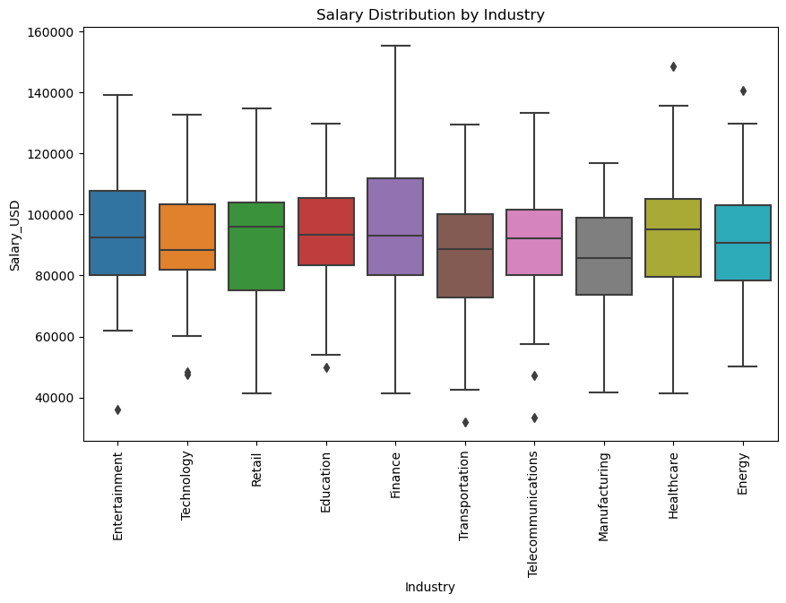

```python
plt.figure(figsize=(10,6))
sns.boxplot(x='Industry', y='Salary_USD', data=df)
plt.xticks(rotation=90)  # Rotate industry names if they overlap
plt.title('Salary Distribution by Industry')
plt.show()
```

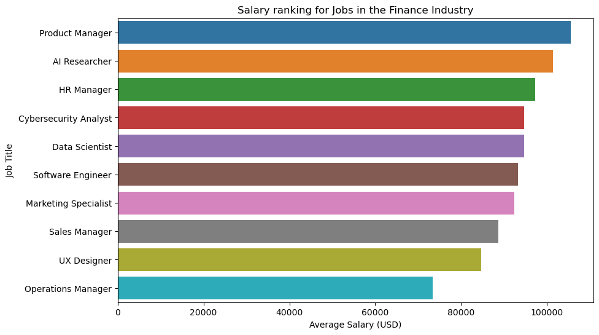

```python
# Filter for Finance industry
finance_jobs = df[df['Industry'] == 'Finance']

# Group by Job_Title and calculate the mean salary
top_finance_jobs = finance_jobs.groupby('Job_Title')['Salary_USD'].mean().reset_index()

# Sort by Salary and select the top 10 highest paying jobs
top_finance_jobs = top_finance_jobs.sort_values(by='Salary_USD', ascending=False)

# Create bar plot
plt.figure(figsize=(10,6))
sns.barplot(x='Salary_USD', y='Job_Title', data=top_finance_jobs)

# Customizing plot
plt.title('Salary ranking for Jobs in the Finance Industry')
plt.xlabel('Average Salary (USD)')
plt.ylabel('Job Title')
plt.show()
```

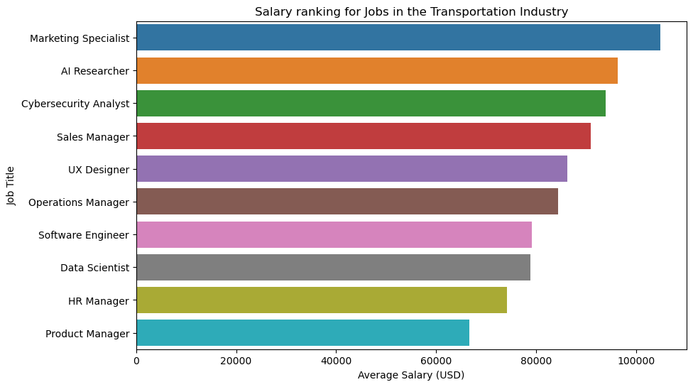

```python
# Filter for Transportation industry
finance_jobs = df[df['Industry'] == 'Transportation']

# Group by Job_Title and calculate the mean salary
top_finance_jobs = finance_jobs.groupby('Job_Title')['Salary_USD'].mean().reset_index()

# Sort by Salary and select the top 10 highest paying jobs
top_finance_jobs = top_finance_jobs.sort_values(by='Salary_USD', ascending=False)

# Create bar plot
plt.figure(figsize=(10,6))
sns.barplot(x='Salary_USD', y='Job_Title', data=top_finance_jobs)

# Customizing plot
plt.title('Salary ranking for Jobs in the Transportation Industry')
plt.xlabel('Average Salary (USD)')
plt.ylabel('Job Title')
plt.show()
```

Interestingly, the highest-paying jobs in finance tend to be Product Manager roles, while the lowest-paying jobs in transportation are also Product Manager roles.

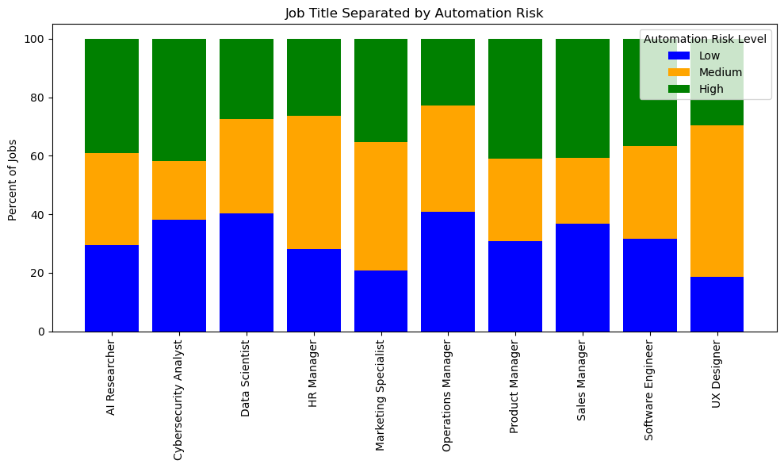

```python
grouped = df.groupby(['Job_Title', 'Automation_Risk']).size().unstack(fill_value=0)
grouped_percent = grouped.div(grouped.sum(axis=1), axis=0) * 100
industries = grouped.index
low_risk = grouped_percent['Low']
medium_risk = grouped_percent['Medium']
high_risk = grouped_percent['High']

plt.figure(figsize=(10, 6))

# Stacked bars
plt.bar(industries, low_risk, label='Low', color='blue')
plt.bar(industries, medium_risk, bottom=low_risk, label='Medium', color='orange')
plt.bar(industries, high_risk, bottom=low_risk+medium_risk, label='High', color='green')

# Rotate x-ticks for better readability
plt.xticks(rotation=90)

# Add a title, y-axis, and legend
plt.title("Job Title Separated by Automation Risk")
plt.legend(title='Automation Risk Level')
plt.ylabel("Percent of Jobs ")
# Show the plot
plt.tight_layout()
plt.show()
```

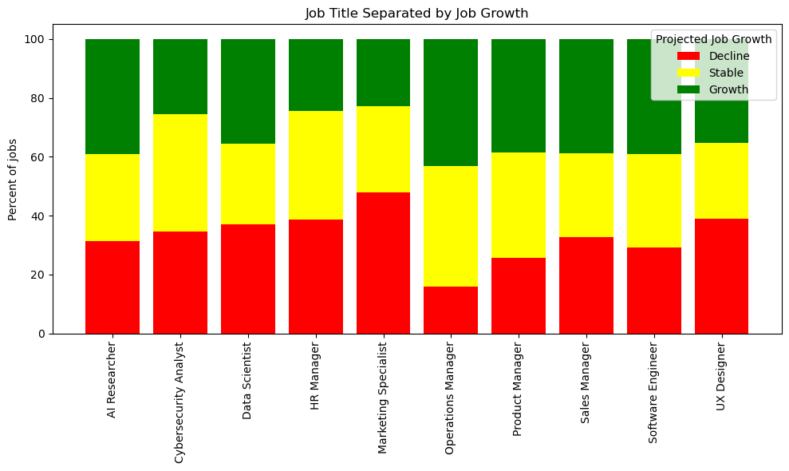

```python
grouped = df.groupby(['Job_Title', 'Job_Growth_Projection']).size().unstack(fill_value=0)
grouped_percent = grouped.div(grouped.sum(axis=1), axis=0) * 100
industries = grouped.index
growth = grouped_percent['Growth']
stable = grouped_percent['Stable']
decline = grouped_percent['Decline']

plt.figure(figsize=(10, 6))

# Stacked bars
plt.bar(industries, decline, label='Decline', color='red')
plt.bar(industries, stable, bottom=decline, label='Stable', color='yellow')
plt.bar(industries, growth, bottom=decline+stable, label='Growth', color='green')

# Rotate x-ticks for better readability
plt.xticks(rotation=90)

# Add a title, y-axis, and legend
plt.title("Job Title Separated by Job Growth")
plt.legend(title='Projected Job Growth')
plt.ylabel("Percent of jobs")
# Show the plot
plt.tight_layout()
plt.show()
```

The jobs with the least ai automation risk are Data Scientist and Operations Manager. The jobs with the most risk are Cyber Security Analyst and Product Manager. When examining the growth of these jobs we can see that Operations Manager has the most growth out of any job and Marketing Specialist has the highest decline rate.

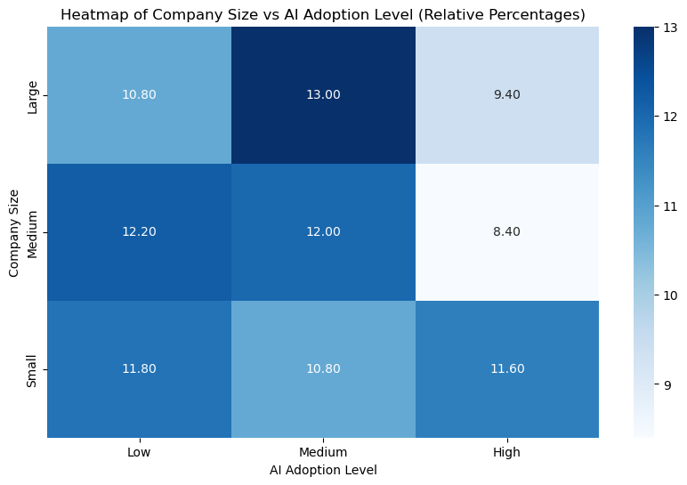

```python
df['AI_Adoption_Level'] = pd.Categorical(df['AI_Adoption_Level'], categories=['Low', 'Medium', 'High'], ordered=True)

cross_tab = pd.crosstab(df['Company_Size'], df['AI_Adoption_Level'])
cross_tab_percent = cross_tab.div(cross_tab.sum().sum()).multiply(100)
# Plot the heatmap
plt.figure(figsize=(10, 6))
sns.heatmap(cross_tab_percent, annot=True, cmap='Blues', fmt='.2f')
plt.title('Heatmap of Company Size vs AI Adoption Level (Relative Percentages)')
plt.xlabel('AI Adoption Level')
plt.ylabel('Company Size')
plt.show()
```

This shows that there is a there is a fairly low and even threat of AI Adoption for different sized companies.

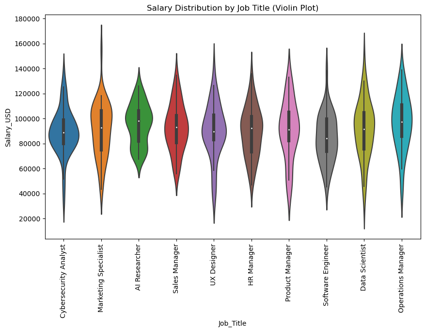

```python
plt.figure(figsize=(10,6))
sns.violinplot(x='Job_Title', y='Salary_USD', data=df)
plt.xticks(rotation=90)
plt.title('Salary Distribution by Job Title (Violin Plot)')
plt.show()
```

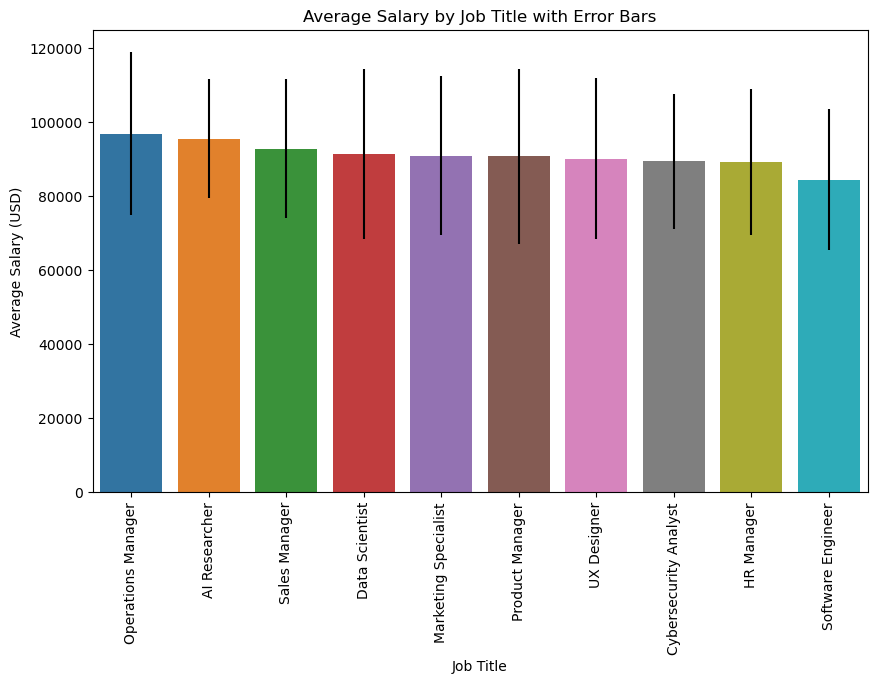

```python
industry_salary = df.groupby('Job_Title')['Salary_USD'].agg(['mean', 'std']).reset_index()
industry_salary = industry_salary.sort_values(by='mean', ascending=False)

plt.figure(figsize=(10,6))
sns.barplot(x='Job_Title', y='mean', data=industry_salary, yerr=industry_salary['std'])
plt.xticks(rotation=90)
plt.title('Average Salary by Job Title with Error Bars')
plt.ylabel('Average Salary (USD)')
plt.xlabel('Job Title')
plt.show()
```

When examining job title without separating by industry we can see the highest paying job, on average, is an Operations Manager, while the lowest paying job is a Software Engineer. These results are interesting given highest paying jobs in the best industries.

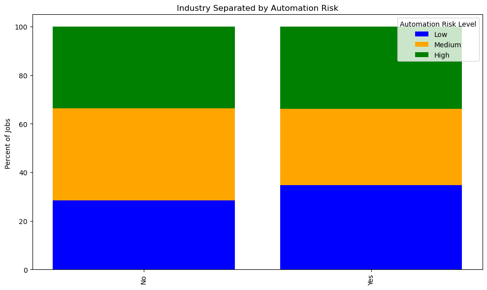

```python
grouped = df.groupby(['Remote_Friendly', 'Automation_Risk']).size().unstack(fill_value=0)
grouped_percent = grouped.div(grouped.sum(axis=1), axis=0) * 100
industries = grouped.index
low_risk = grouped_percent['Low']
medium_risk = grouped_percent['Medium']
high_risk = grouped_percent['High']

plt.figure(figsize=(10, 6))

# Stacked bars
plt.bar(industries, low_risk, label='Low', color='blue')
plt.bar(industries, medium_risk, bottom=low_risk, label='Medium', color='orange')
plt.bar(industries, high_risk, bottom=low_risk+medium_risk, label='High', color='green')

# Rotate x-ticks for better readability
plt.xticks(rotation=90)

# Add a title, y-axis, and legend
plt.title("Industry Separated by Automation Risk")
plt.legend(title='Automation Risk Level')
plt.ylabel("Percent of Jobs ")
# Show the plot
plt.tight_layout()
plt.show()
```

Remote friendly jobs have a slightly lower automation risk level, but they are still very similar